# Practical Lab-1 Rohit Kumar 8895806

## Box Plot:

Box plot, also known as box-and-whisker plot, helps us to study the distribution of the data. It is a very convenient way to visualize the spread and skew of the data.

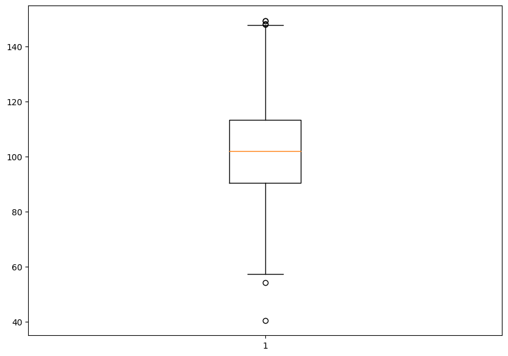

```python
import matplotlib.pyplot as plt
import numpy as np


np.random.seed(10)
data = np.random.normal(100, 20, 200)

fig = plt.figure(figsize =(10, 7))

plt.boxplot(data)

plt.show()
```

# Part B

#### 1.Solve the following two system of linear equations using matrices (find the values of x1 and x2) and determine the number of solutions using the functions.

##### Defining the feature matrix for given set of solutions 2x1+3x2-4x3 = 6; x1-4x2+0x3 = 8

```python
# Defining the feature matrix for given set of solutions 2x1+3x2-4x3 = 6; x1-4x2+0x3 = 8

A = np.array([[2,3,-4],[1,-4,0]])

# Defining the constants matrix for given set of equations

B = np.array([6,8])

print("The shape of A matrix is: \n", A.shape)
print("The shape of B matrix is: \n", B.shape)

solution = np.linalg.solve(A, B)
```

```
The shape of A matrix is:
 (2, 3)
The shape of B matrix is:
 (2,)
```

[output not shown]

As I can check Error "Last 2 dimensions of the array must be square", A matrix is 2 x 3, which is a non-square matrix. Thats why it is not executing solution.

```python
#  3y1-4y2+5y3 = 10; -y1+2y2-4y3 = 8

P = np.array([[3,-4,5],[-1,2,-4]])

# Defining the constants matrix for given set of equations

Q = np.array([10,8])

print("The shape of P matrix is: \n", P.shape)
print("The shape of Q matrix is: \n", Q.shape)
```

[output not shown]

[output not shown]